# Stats 506 Problem Set 2

Author

Yannan Niu

## Github Link

https://github.com/nynn7747/Stats_506_PS2

## Problem 1

### a. Four versions of play_dice

```r
#' Version 1: Implement this game using a loop.
#' @param x: the number of dice to roll
#' @function play_dice1: a function to get the results of dice game with loop
#' @return winnings: Total winnings

set.seed(27)

play_dice1 <- function(x) {
    # Create a vector for money of each roll
    scores <- rep(0, x)
    # Roll the dice x times
    for (i in 1:x) {
      result <- sample(1:6, size = 1)
      # Get scores based on the roll
      if (result == 3 | result == 5){
        get_score <- 4-2
      } else {
        get_score <- -2
        }
      scores[i] <- get_score
    }
    winnings <- sum(scores)
    # Sum money across all rolls
    return(winnings)
}
play_dice1(10)
```

```
[1] -12
```

```r
play_dice1(10)
```

```
[1] -4
```

```r
#' Version 2: Implement this game using built-in R vectorized functions.
#' @param x: the number of dice to roll
#' @function play_dice2: a function to get the results of dice game with built-in R vectorized functions.
#' @return winnings: Total winnings

set.seed(27)

play_dice2 <- function(x) {
    results <- sample(1:6, size = x, replace = TRUE)
    get_scores <- ifelse(results == 3 | results == 5, 4, 0)
    winnings <- sum(get_scores -2)
    return(winnings)
}
play_dice2(10)
```

```
[1] -12
```

```r
play_dice2(10)
```

```
[1] -4
```

```r
#' Version 3:  Implement this by rolling all the dice into one and collapsing the die rolls into a single table()
#' @param x: the number of dice to roll
#' @function play_dice3: a function to get the results of dice game with table()
#' @return winnings: Total winnings

set.seed(27)

play_dice3 <- function(x) {
    results <- sample(1:6, size = x, replace = TRUE)
    results_table <- table(results)
    number_3 <- ifelse(is.na(results_table["3"]), 0, results_table["3"])
    number_5 <- ifelse(is.na(results_table["5"]), 0, results_table["5"])

    winnings <- as.numeric((-2)*x + 4*(number_3 + number_5))
    return(winnings)
}

play_dice3(10)
```

```
[1] -12
```

```r
play_dice3(10)
```

```
[1] -4
```

```r
#' Version 4: Implement this game by using one of the “apply” functions
#' @param x: the number of dice to roll
#' @function play_dice4: a function to get the results of dice game with "apply"
#' @return winnings: Total winnings

set.seed(27)

play_dice4 <- function(x) {
  results <- matrix(sample(1:6, size = x, replace = TRUE))
  scores <- apply(results, c(1,2), function(r) {
    if (r == 3 | r == 5) {score = 4 - 2}
    else {score = -2}
    return(score)
  })
  winnings <- sum(scores)
  return(winnings)
}
play_dice4(10)
```

```
[1] -12
```

```r
play_dice4(10)
```

```
[1] -4
```

### b & c. Demonstrate that all versions work and that the four versions give the same result. Do so by running each a few times, once with an input a 3, and once with an input of 3,000.

```r
set.seed(330)
print("Result from Version 1")
```

```
[1] "Result from Version 1"
```

```r
sapply(c(3, 3000), play_dice1)
```

```
[1]    -6 -2052
```

```r
set.seed(330)
print("Result from Version 2")
```

```
[1] "Result from Version 2"
```

```r
sapply(c(3, 3000), play_dice2)
```

```
[1]    -6 -2052
```

```r
set.seed(330)
print("Result from Version 3")
```

```
[1] "Result from Version 3"
```

```r
sapply(c(3, 3000), play_dice3)
```

```
[1]    -6 -2052
```

```r
set.seed(330)
print("Result from Version 4")
```

```
[1] "Result from Version 4"
```

```r
sapply(c(3, 3000), play_dice4)
```

```
[1]    -6 -2052
```

### d. Use the *microbenchmark* package to clearly demonstrate the speed of the implementations. Compare performance with a low input (1,000) and a large input (100,000). Discuss the results

**According to the output of microbenchmark function, Version 2 using vectorization is faster than other methods. Loop-based version 1 is the slowest although this is easier to understand. Apply and table functions in version 3 and 4 have a performance between vectorization and loop. In our actual work, vectorization should be preferred.**

```r
library(microbenchmark)

microbenchmark("Version 1" = play_dice1(1000),
               "Version 2" = play_dice2(1000),
               "Version 3" = play_dice3(1000),
               "Version 4" = play_dice4(1000))
```

```
Unit: microseconds
      expr      min       lq       mean    median        uq      max neval cld
 Version 1 2887.712 2907.372 3118.16275 2936.8505 3033.5695 7087.629   100 a
 Version 2   64.657   67.650   72.07759   70.9095   74.7020   94.177   100  b
 Version 3  129.560  142.106  163.13736  153.8525  172.3435  266.746   100  b
 Version 4  798.024  810.611  865.02579  822.2960  846.5680 2042.374   100   c
```

```r
microbenchmark("Version 1" = play_dice1(100000),
               "Version 2" = play_dice2(100000),
               "Version 3" = play_dice3(100000),
               "Version 4" = play_dice4(100000))
```

```
Unit: milliseconds
      expr        min         lq       mean     median         uq       max
 Version 1 310.263072 327.007944 350.250434 348.103530 361.552452 491.45679
 Version 2   5.921630   6.070521   6.480957   6.126630   6.212791  22.18260
 Version 3   7.329201   7.512861   8.121651   7.597259   7.738197  33.10065
 Version 4  86.719961  95.027935 107.455745 101.999472 116.349390 200.05901
 neval cld
   100 a
   100  b
   100  b
   100   c
```

### e. Do you think this is a fair game? Defend your decision with evidence based upon a Monte Carlo simulation.

**I don’t think this is a fair game based on the expected value and Monte Carlo simulations. This game is not in favor of the player based on the negative values in the expected value and the simulation result.**

**Expected value:**

$E(x) = x \times \left[(-2) \times \frac{4}{6} + (4 - 2) \times \frac{2}{6}\right]$

**This simplifies to:**

$E(x) = -\frac{2x}{3} < 0$

**With Monte Carlo simulation, based on 1000 times simulations, no matter we have 10, 100, or 1000 rolls, the winnings are less than 0.**

```r
sim_n <- 1000

rolls <- c(10, 100, 1000)
sim_m <- matrix(sapply(rolls, function(r) replicate(sim_n, play_dice2(r)))
, ncol = 3)
#  rep(play_dice2(1000),c(10, 100, 1000))
apply(sim_m, 2, mean)
```

```
[1]   -6.340  -66.940 -669.924
```

## Problem 2 **- Linear Regression**

### a. The names of the variables in this data are way too long. Rename the columns of the data to more reasonable lengths.

```r
cars <- read.csv("/Users/nynn/Library/CloudStorage/OneDrive-Umich/Umich course/2024_Fall/Stats 506/Stats_506_PS2/cars.csv")
names(cars)
```

```
 [1] "Dimensions.Height"
 [2] "Dimensions.Length"
 [3] "Dimensions.Width"
 [4] "Engine.Information.Driveline"
 [5] "Engine.Information.Engine.Type"
 [6] "Engine.Information.Hybrid"
 [7] "Engine.Information.Number.of.Forward.Gears"
 [8] "Engine.Information.Transmission"
 [9] "Fuel.Information.City.mpg"
[10] "Fuel.Information.Fuel.Type"
[11] "Fuel.Information.Highway.mpg"
[12] "Identification.Classification"
[13] "Identification.ID"
[14] "Identification.Make"
[15] "Identification.Model.Year"
[16] "Identification.Year"
[17] "Engine.Information.Engine.Statistics.Horsepower"
[18] "Engine.Information.Engine.Statistics.Torque"
```

```r
new_names <- c("Height", "Length", "Width", "Driveline", "Eng_type",
                 "Hybrid", "Fwd_Gears", "Transmission", "City_mpg", "Fuel_Type",
                 "Highway_mpg", "Classification", "ID", "Make", "Model_year",
                 "Year", "Horsepower", "Torque")
length(new_names)
```

```
[1] 18
```

```r
names(cars) <- new_names
```

### b. Restrict the data to cars whose Fuel Type is “Gasoline”.

```r
cars_gas <- cars[cars$Fuel_Type == "Gasoline", ]
dim(cars_gas)
```

```
[1] 4591   18
```

### c. Examine the distribution of highway gas mileage. Consider whether a transformation could be used. If so, generate the transformed variable and *use this variable going forward*. If not, provide a short justification.

**Highway gas mileage has a right-skewed distribution. Therefore, a log transformation would be helpful to data analysis.**

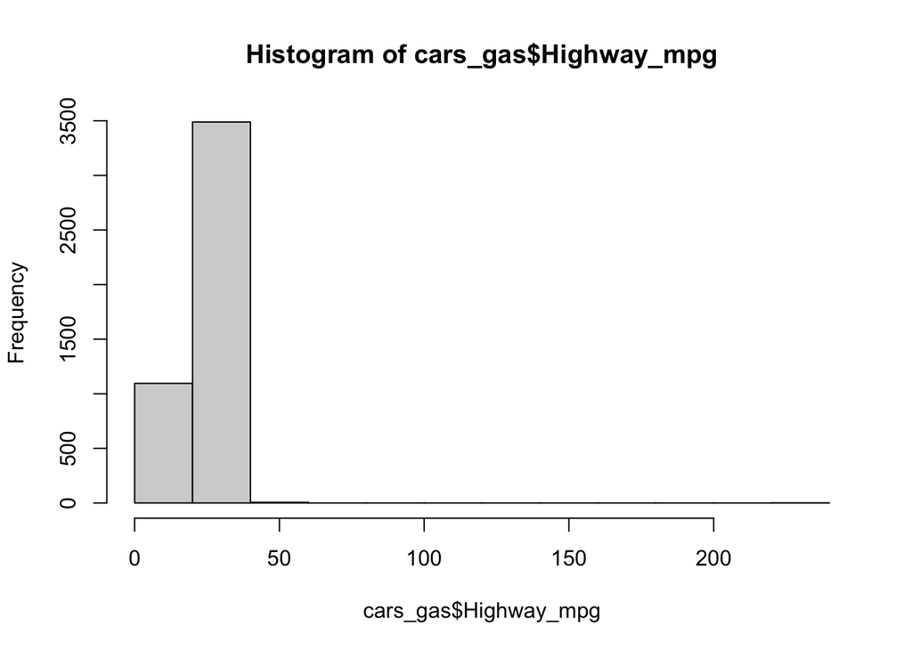

```r
hist(cars_gas$Highway_mpg)
```

```r
summary(cars_gas$Highway_mpg)
```

```
   Min. 1st Qu.  Median    Mean 3rd Qu.    Max.
  13.00   21.00   25.00   24.97   28.00  223.00
```

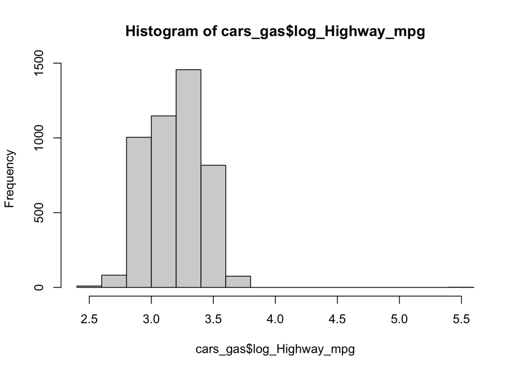

```r
# Log transformation
cars_gas$log_Highway_mpg <- log(cars_gas$Highway_mpg)
# View the distribution again
hist(cars_gas$log_Highway_mpg)
```

```r
summary(cars_gas$log_Highway_mpg)
```

```
   Min. 1st Qu.  Median    Mean 3rd Qu.    Max.
  2.565   3.045   3.219   3.194   3.332   5.407
```

### d. Fit a linear regression model predicting MPG on the highway. The predictor of interest is torque. Control for:

- The horsepower of the engine
- All three dimensions of the car
- The year the car was released, as a categorical variable.

Briefly discuss the estimated relationship between torque and highway MPG. Be precise about the interpretation of the estimated coefficient.

**The estimated coefficient for torque is -0.0023 with a significant *p*-value. This means that for every one-unit increase in torque, the log of highway miles per gallon decrease by 0.0023 units, after controlling for horsepower, dimensions (height, length, width), and the year of release. Therefore, cars with higher torque generally have lower fuel efficiency on highways.**

```r
library(tidyverse)
# the formula for regression, based on the previous, use log-transferred mpg
form1 <- log_Highway_mpg ~ Torque + Horsepower + Height + Length + Width + as.factor(Year)

head(model.frame(form1, data = cars_gas))
```

```
  log_Highway_mpg Torque Horsepower Height Length Width as.factor(Year)
1        3.218876    236        250    140    143   202            2009
2        3.332205    207        200    140    143   202            2009
3        3.401197    207        200    140    143   202            2009
4        3.332205    207        200    140    143   202            2009
5        3.332205    207        200    140    143   202            2009
6        3.295837    243        265     91     17    62            2009
```

```r
summary(lm(form1, data = cars_gas))
```

```
Call:
lm(formula = form1, data = cars_gas)

Residuals:
     Min       1Q   Median       3Q      Max
-0.54759 -0.09385 -0.00414  0.09894  2.41852

Coefficients:
                      Estimate Std. Error t value Pr(>|t|)
(Intercept)          3.507e+00  2.216e-02 158.236  < 2e-16 ***
Torque              -2.294e-03  6.757e-05 -33.956  < 2e-16 ***
Horsepower           9.238e-04  6.984e-05  13.227  < 2e-16 ***
Height               4.050e-04  3.456e-05  11.719  < 2e-16 ***
Length               3.475e-05  2.710e-05   1.282  0.19980
Width               -8.722e-05  2.774e-05  -3.144  0.00168 **
as.factor(Year)2010 -2.181e-02  2.076e-02  -1.051  0.29342
as.factor(Year)2011 -2.430e-03  2.072e-02  -0.117  0.90665
as.factor(Year)2012  4.012e-02  2.089e-02   1.921  0.05485 .
---
Signif. codes:  0 '***' 0.001 '**' 0.01 '*' 0.05 '.' 0.1 ' ' 1

Residual standard error: 0.1412 on 4582 degrees of freedom
Multiple R-squared:  0.5638,    Adjusted R-squared:  0.563
F-statistic: 740.3 on 8 and 4582 DF,  p-value: < 2.2e-16
```

### e. It seems reasonable that there may be an interaction between torque and horsepower. Refit the model (with `lm`) and generate an interaction plot, showing how the relationship between torque and MPG changes as horsepower changes. Choose reasonable values of torque, and show lines for three different reasonable values of horsepower.

(Hint: If you choose to use the *interactions* package for this, look at the `at =` argument to help with how year comes into play - choose a reasonable single value for year.

**The interaction coefficient for Torque:Horsepower is 3.939e-06. This means that the association between torque and highway MPG is related to horsepower. For every additional unit of horsepower, the negative impact of torque on log value of highway MPG decreases by 3.939e-06 units.**

```r
# A new formula with interation Torque:Horsepower
form2 <- log_Highway_mpg ~ Torque + Horsepower + Height + Length + Width + as.factor(Year) + Torque:Horsepower
head(model.frame(form2, data = cars_gas))
```

```
  log_Highway_mpg Torque Horsepower Height Length Width as.factor(Year)
1        3.218876    236        250    140    143   202            2009
2        3.332205    207        200    140    143   202            2009
3        3.401197    207        200    140    143   202            2009
4        3.332205    207        200    140    143   202            2009
5        3.332205    207        200    140    143   202            2009
6        3.295837    243        265     91     17    62            2009
```

```r
model2 <- lm(form2, data = cars_gas)
summary(model2)
```

```
Call:
lm(formula = form2, data = cars_gas)

Residuals:
     Min       1Q   Median       3Q      Max
-0.55760 -0.08378 -0.00157  0.08194  2.45015

Coefficients:
                      Estimate Std. Error t value Pr(>|t|)
(Intercept)          3.854e+00  2.384e-02 161.669  < 2e-16 ***
Torque              -3.533e-03  7.615e-05 -46.390  < 2e-16 ***
Horsepower          -2.339e-04  7.632e-05  -3.064  0.00219 **
Height               2.876e-04  3.215e-05   8.946  < 2e-16 ***
Length               3.643e-05  2.500e-05   1.457  0.14525
Width               -1.165e-04  2.561e-05  -4.548 5.55e-06 ***
as.factor(Year)2010 -2.563e-02  1.915e-02  -1.338  0.18095
as.factor(Year)2011 -5.886e-03  1.912e-02  -0.308  0.75822
as.factor(Year)2012  3.640e-02  1.927e-02   1.889  0.05896 .
Torque:Horsepower    3.939e-06  1.391e-07  28.314  < 2e-16 ***
---
Signif. codes:  0 '***' 0.001 '**' 0.01 '*' 0.05 '.' 0.1 ' ' 1

Residual standard error: 0.1302 on 4581 degrees of freedom
Multiple R-squared:  0.6288,    Adjusted R-squared:  0.628
F-statistic: 862.1 on 9 and 4581 DF,  p-value: < 2.2e-16
```

```r
summary(cars_gas$Horsepower)
```

```
   Min. 1st Qu.  Median    Mean 3rd Qu.    Max.
  100.0   185.0   263.0   267.5   317.0   638.0
```

```r
summary(cars_gas$Torque)
```

```
   Min. 1st Qu.  Median    Mean 3rd Qu.    Max.
   98.0   177.0   257.0   267.2   332.0   774.0
```

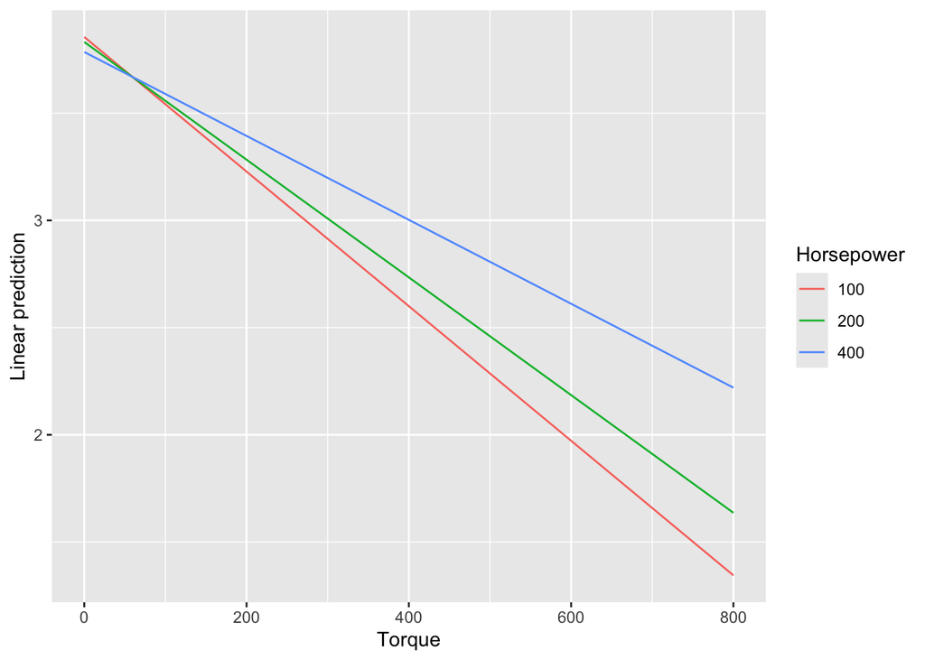

```r
library(emmeans)
torque_vals <- seq(0, 800, by = 100)  # Torque values based on the range
hp_vals <- c(100, 200, 400)      # Horsepower values based on the range

# Generate an interaction plot at Year= 2011
emmip(model2, Horsepower ~ Torque, at = list(Torque = torque_vals, Horsepower = hp_vals, Year = 2011))
```

### f. Calculate β^ from d. manually (without using `lm`) by first creating a proper design matrix, then using matrix algebra to estimate β. Confirm that you get the same result as `lm` did prior.

```r
# Recall the lm result
form1 <- log_Highway_mpg ~ Torque + Horsepower + Height + Length + Width + as.factor(Year)
mod <- lm(form1, data = cars_gas)
summary(lm(form1, data = cars_gas))
```

```
Call:
lm(formula = form1, data = cars_gas)

Residuals:
     Min       1Q   Median       3Q      Max
-0.54759 -0.09385 -0.00414  0.09894  2.41852

Coefficients:
                      Estimate Std. Error t value Pr(>|t|)
(Intercept)          3.507e+00  2.216e-02 158.236  < 2e-16 ***
Torque              -2.294e-03  6.757e-05 -33.956  < 2e-16 ***
Horsepower           9.238e-04  6.984e-05  13.227  < 2e-16 ***
Height               4.050e-04  3.456e-05  11.719  < 2e-16 ***
Length               3.475e-05  2.710e-05   1.282  0.19980
Width               -8.722e-05  2.774e-05  -3.144  0.00168 **
as.factor(Year)2010 -2.181e-02  2.076e-02  -1.051  0.29342
as.factor(Year)2011 -2.430e-03  2.072e-02  -0.117  0.90665
as.factor(Year)2012  4.012e-02  2.089e-02   1.921  0.05485 .
---
Signif. codes:  0 '***' 0.001 '**' 0.01 '*' 0.05 '.' 0.1 ' ' 1

Residual standard error: 0.1412 on 4582 degrees of freedom
Multiple R-squared:  0.5638,    Adjusted R-squared:  0.563
F-statistic: 740.3 on 8 and 4582 DF,  p-value: < 2.2e-16
```

```r
# Compute beta_hat
matrix <- model.matrix(form1, data = cars_gas)
head(matrix)
```

```
  (Intercept) Torque Horsepower Height Length Width as.factor(Year)2010
1           1    236        250    140    143   202                   0
2           1    207        200    140    143   202                   0
3           1    207        200    140    143   202                   0
4           1    207        200    140    143   202                   0
5           1    207        200    140    143   202                   0
6           1    243        265     91     17    62                   0
  as.factor(Year)2011 as.factor(Year)2012
1                   0                   0
2                   0                   0
3                   0                   0
4                   0                   0
5                   0                   0
6                   0                   0
```

```r
y <- cars_gas$log_Highway_mpg

# beta_hat = (X^T X)^{-1} X^T y
beta_hat <- solve(t(matrix) %*% matrix) %*% (t(matrix) %*% y)
print(beta_hat)
```

```
                             [,1]
(Intercept)          3.506922e+00
Torque              -2.294331e-03
Horsepower           9.238126e-04
Height               4.049897e-04
Length               3.475207e-05
Width               -8.722295e-05
as.factor(Year)2010 -2.181247e-02
as.factor(Year)2011 -2.430359e-03
as.factor(Year)2012  4.011528e-02
```

```r
# Compare the result
all.equal(coefficients(mod), beta_hat[, 1])
```

```
[1] TRUE
```